Data Types and Operations

This is a notebook used as 'slides' for the class 2 on **data types and operations**

# Intro: Data Types and Operations

Data is stored into objects.

- A constant is an object
- A variable is an object
- Actually, everything in Python is an object.
  - We will see more on this in the coming weeks

Every object has a *type*

- The notion of type is very important in computer science.
- In Python they are less evident than in other programming languages. But still, everything has a type in Python.

We are going to discuss some of the [Built-in Python types](https://docs.python.org/3/library/stdtypes.html)

- **Booleans**
- **Numerics (int & float)**
- **Strings**
- **And how to transform from one type to another**

# Boolean data type

```python
False
```

```
False
```

```python
True
```

```
True
```

```python
print(False,'has type',type(False))
print(True,'has type',type(True))
```

```
False has type <class 'bool'>
True has type <class 'bool'>
```

This is all reasonable but... what can we do with Booleans?  
Boolean expressions

## Boolean expressions and comparisons

We can build expressions of Booleans

```python
not True
```

```
False
```

```python
True and False
```

```
False
```

```python
True or False
```

```
True
```

We can create Boolean variables

```python
v=False
print(v,'has type',type(v))
v=True
```

```
False has type <class 'bool'>
```

We can also compare Booleans

```python
v=False
print('Is v True?',v==True)
v=True
print('Is v True?',v==True)
```

```
Is v True? False
Is v True? True
```

## Short-cicruiting

What happens if I evaluated the following expression?

```python
False and (v1000 == True)
```

```
False
```

What happens if I evaluated the following expression? And why?

```python
True and (v1000 == True)
```

```
---------------------------------------------------------------------------
NameError                                 Traceback (most recent call last)
<ipython-input-10-4ccdd88ca310> in <module>
----> 1 True and (v1000 == True)

NameError: name 'v1000' is not defined
```

## Are Booleans useful?

In the coming classes we will see that Boolean expressions are fundamental to write *interesting* programs. They allow us to decide wheter:

- A block of instructions should be executed or not
- A block of instructions should be executed 0, 1, or more times ...

# Numeric data types

## Integers and reals

We are going to use

- `int` (integers)
- `float` (real values)

```python
5
n=5
```

```python
type(5)
```

```
int
```

```python
type(n)
```

```
int
```

> Actually, everything has type. Even the `type` of an object has a type. The name of this type is `type` :D

> If you execute `type(type(n))` you get `type`

```python
type(type(n))
```

```
type
```

```python
v=5
print(v,'has type',type(v))
v=-5
print(v,'has type',type(v))
v=5.1
print(v,'has type',type(v))
v=1.2e-3
print(v,'has type',type(v))
v=1.2E-3
print(v,'has type',type(v))
v=1.2e+3
print(v,'has type',type(v))
```

```
5 has type <class 'int'>
-5 has type <class 'int'>
5.1 has type <class 'float'>
0.0012 has type <class 'float'>
0.0012 has type <class 'float'>
1200.0 has type <class 'float'>
```

There are also other numeric types, but we are not going to use them

- binary, octal, hexadecimal numbers
- complex numbers

## Comparison operations

> Sneak preview:
> - The above is done using features of the editor similar to those for having titles, bullet points, etc.
> - However, we can just as well use Python to write a program that visualizes an image...

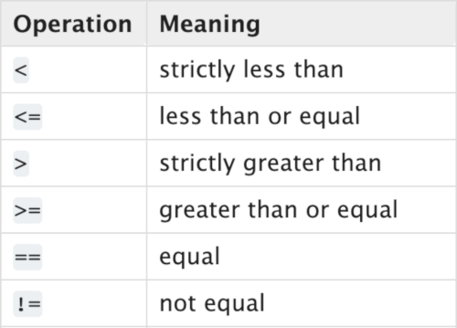

```python
from IPython.display import Image, display
img=Image(filename='images/comparisonOperationsNoIs.png')
display(img)
```

These have the expected meaning (or *semantics*)

```python
print('5 < 7',5 < 7)
print('7 < 5',7 < 5)
v1=5
v2=v1
print('v2 == v1',v2 == v1)
```

```
5 < 7 True
7 < 5 False
v2 == v1 True
```

> Beware: `v1 = v2` **IS NOT THE SAME AS** `v1 == v2`
> - `v1 = v2` assigns the value of `v2` to `v1`
> - `v1 == v2` compares `v2` and `v1` without modifying them

```python
    v1 = 10
    v1==v2
    print('After v1==v2 v1 is',v1)
    v1=v2
    print('After v1=v2 v1 is',v1)
```

```
After v1==v2 v1 is 10
After v1=v2 v1 is 5
```

## Arithmetic operations

- + addition
- - subtraction
- * multiplication
- / division
- % remainder
- // floor division
- ** exponentiation
- abs() absolute value

```python
print('5+2   =',5+2)
print('5-2   =',5-2)
print('4.1*2 =',4.1*2)
print('4.1/2 =',4.1/2)
print('5/2   =',5/2)
print('5%2   =',5%2)
print('5//2  =',5//2)
print('5**2  =',5**2)
print('abs(-5)',abs(-5))
```

```
5+2   = 7
5-2   = 3
4.1*2 = 8.2
4.1/2 = 2.05
5/2   = 2.5
5%2   = 1
5//2  = 2
5**2  = 25
abs(-5) 5
```

```python
# Floor does not round to the closest integer, but towards the smallest.
print(' 0.1/2  = ',0.1/2)
print(' 0.1//2 = ',0.1//2)

print('-0.1/2  =',-0.1/2)
print('-0.1//2 =',-0.1//2)
```

```
 0.1/2  =  0.05
 0.1//2 =  0.0
-0.1/2  = -0.05
-0.1//2 = -1.0
```